# R Bootcamp 2.3 Regression

last updated: 2021-10-26

## Regression

> Whenever the correlation between two scores is imperfect, there will be regression to the mean.

-Francis Galton

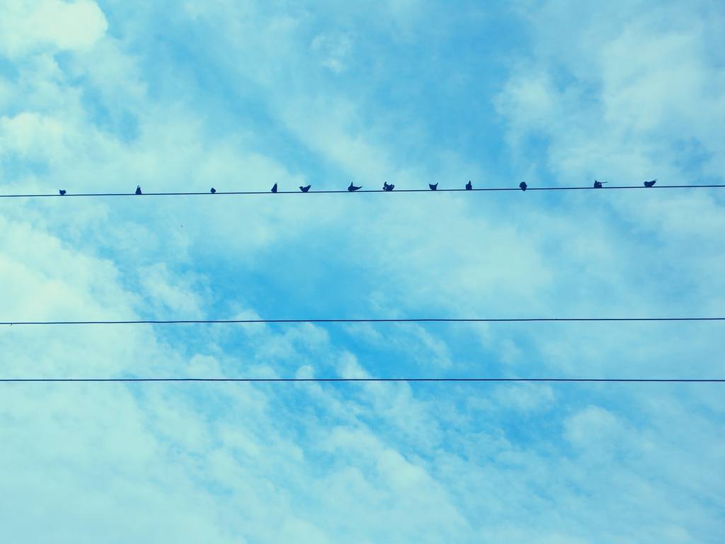

## Regression

**Linear regression** is a foundational tool for scientists

## What you will learn

- The question of simple linear regression
- Data and assumptions
- Graphing
- Tests and alternatives
- Practice exercises

## The question of simple linear regression

“Does X explain significant variation in Y”

The main question we tend to ask is whether the slope of the regression is different than zero

\(Y = \alpha + \beta X + \epsilon\)

## Data and assumptions

Formal assumptions

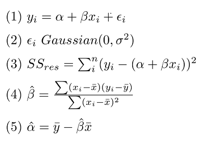

## Data and assumptions

Informal assumptions (the ones we have responsibility to evaluate)

- (Relationship is linear)
- (Numeric continuous data)
- The residuals are “Gaussian”
- Homoscedasticity
- Independence of observations

## Data and assumptions

**Kaggle Fish market data**

**Species**, character, fish spp

**Weight**, numeric, weight in grams

**Length1**, numeric, vertical length in cm

**Length2**, numeric, diagonal length in cm

**Length3**, numeric, cross length in cm

**Height**, numeric, height in cm

**Width**, numeric, diagonal width in cm

https://www.kaggle.com/aungpyaeap/fish-market

## Data and assumptions

```r
library(openxlsx)
dat <- read.xlsx('data/2.4-fish.xlsx')
head(dat)
```

```
##   Species Weight Length1 Length2 Length3  Height  Width
## 1   Bream    242    23.2    25.4    30.0 11.5200 4.0200
## 2   Bream    290    24.0    26.3    31.2 12.4800 4.3056
## 3   Bream    340    23.9    26.5    31.1 12.3778 4.6961
## 4   Bream    363    26.3    29.0    33.5 12.7300 4.4555
## 5   Bream    430    26.5    29.0    34.0 12.4440 5.1340
## 6   Bream    450    26.8    29.7    34.7 13.6024 4.9274
```

## Data and assumptions

Slice out perch

```r
dat$Species == 'Perch'
```

```
##   [1] FALSE FALSE FALSE FALSE FALSE FALSE FALSE FALSE FALSE FALSE FALSE FALSE
##  [13] FALSE FALSE FALSE FALSE FALSE FALSE FALSE FALSE FALSE FALSE FALSE FALSE
##  [25] FALSE FALSE FALSE FALSE FALSE FALSE FALSE FALSE FALSE FALSE FALSE FALSE
##  [37] FALSE FALSE FALSE FALSE FALSE FALSE FALSE FALSE FALSE FALSE FALSE FALSE
##  [49] FALSE FALSE FALSE FALSE FALSE FALSE FALSE FALSE FALSE FALSE FALSE FALSE
##  [61] FALSE FALSE FALSE FALSE FALSE FALSE FALSE FALSE FALSE FALSE FALSE FALSE
##  [73]  TRUE  TRUE  TRUE  TRUE  TRUE  TRUE  TRUE  TRUE  TRUE  TRUE  TRUE  TRUE
##  [85]  TRUE  TRUE  TRUE  TRUE  TRUE  TRUE  TRUE  TRUE  TRUE  TRUE  TRUE  TRUE
##  [97]  TRUE  TRUE  TRUE  TRUE  TRUE  TRUE  TRUE  TRUE  TRUE  TRUE  TRUE  TRUE
## [109]  TRUE  TRUE  TRUE  TRUE  TRUE  TRUE  TRUE  TRUE  TRUE  TRUE  TRUE  TRUE
## [121]  TRUE  TRUE  TRUE  TRUE  TRUE  TRUE  TRUE  TRUE FALSE FALSE FALSE FALSE
## [133] FALSE FALSE FALSE FALSE FALSE FALSE FALSE FALSE FALSE FALSE FALSE FALSE
## [145] FALSE FALSE FALSE FALSE FALSE FALSE FALSE FALSE FALSE FALSE FALSE FALSE
## [157] FALSE FALSE FALSE
```

## Data and assumptions

Slice out perch

```r
perch <- dat[dat$Species == "Perch" , ]
head(perch)
```

```
##    Species Weight Length1 Length2 Length3 Height  Width
## 73   Perch    5.9     7.5     8.4     8.8 2.1120 1.4080
## 74   Perch   32.0    12.5    13.7    14.7 3.5280 1.9992
## 75   Perch   40.0    13.8    15.0    16.0 3.8240 2.4320
## 76   Perch   51.5    15.0    16.2    17.2 4.5924 2.6316
## 77   Perch   70.0    15.7    17.4    18.5 4.5880 2.9415
## 78   Perch  100.0    16.2    18.0    19.2 5.2224 3.3216
```

## Graphing regression

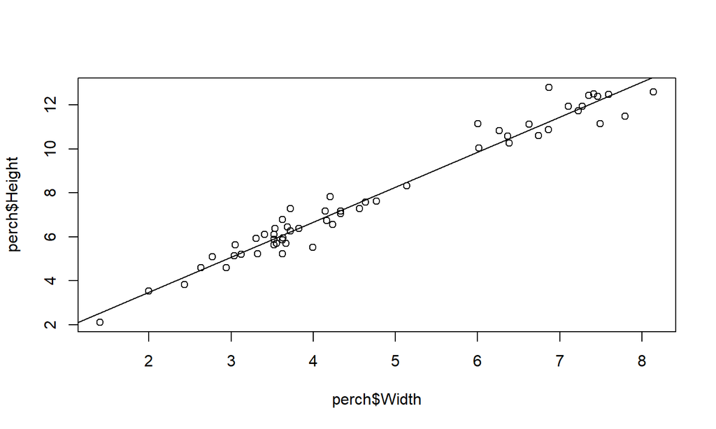

```r
# literally the least you can do
plot(y = perch$Height, x = perch$Width)
lm0_perch <- lm(Height ~ Width, data = perch)
abline(lm0_perch)
```

## Graphing regression

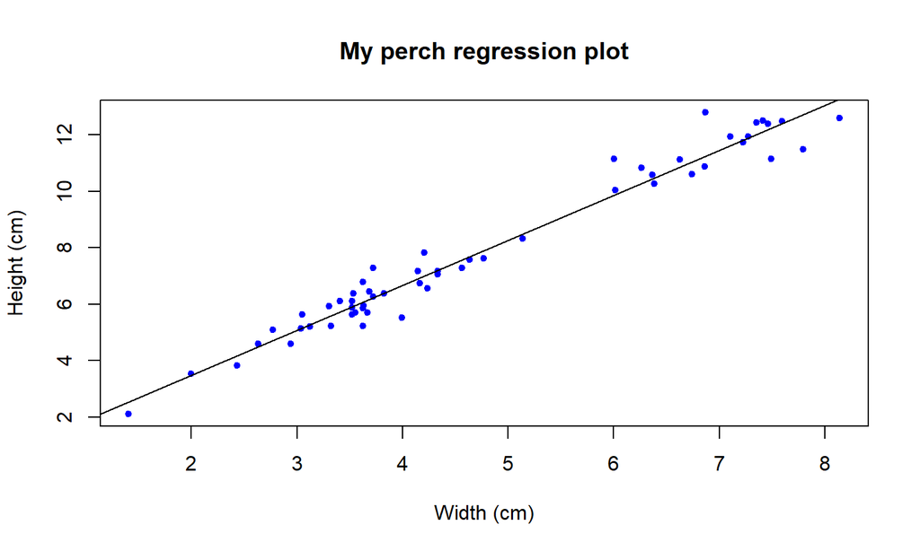

```r
plot(y = perch$Height, x = perch$Width,
     ylab = "Height (cm)", xlab = "Width (cm)",
     main = "My perch regression plot",
     pch = 20, col = "blue", cex = 1)

abline(lm0_perch)
```

## Graphing regression

Residuals Gaussian?

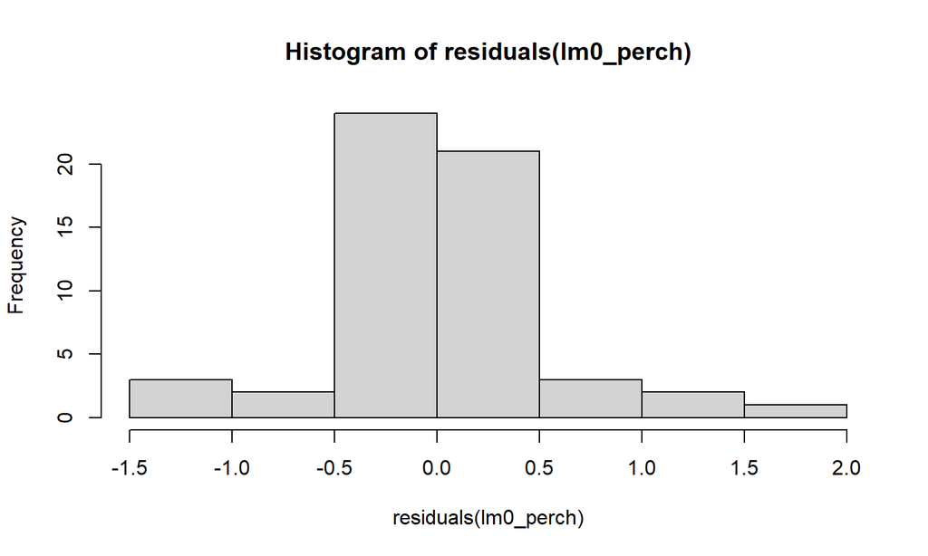

```r
hist(residuals(lm0_perch))
```

## Graphing regression

Residuals Gaussian?

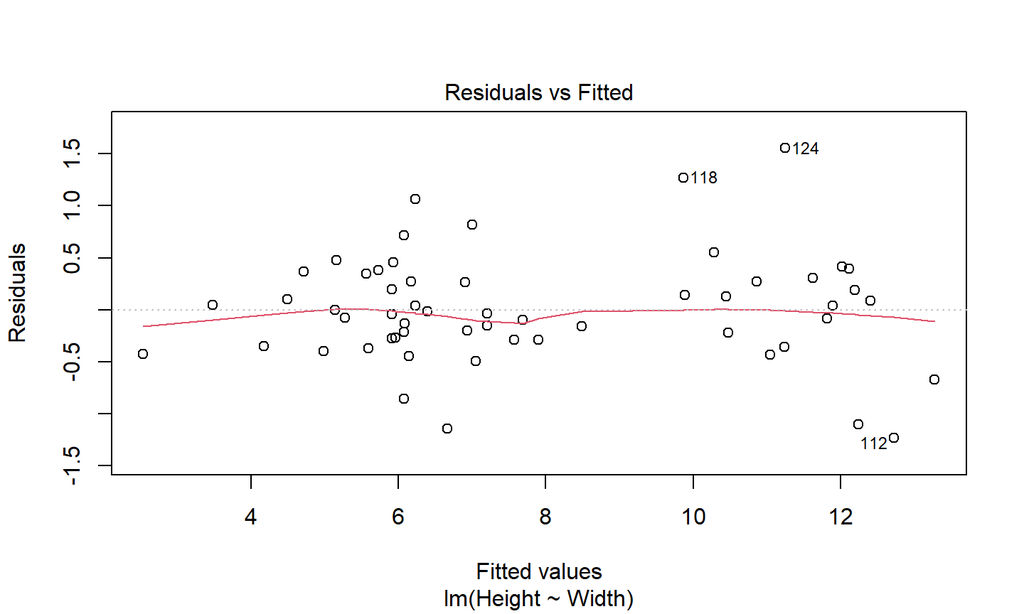

```r
plot(x = lm0_perch, which = 1)
```

## Graphing regression

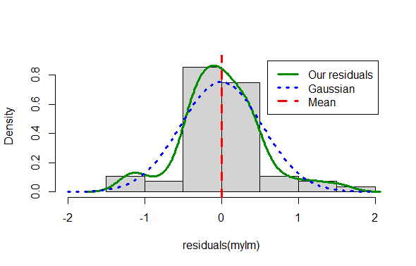

## Graphing regression

Sometimes a statistical test may be used to diagnose the distribution

```r
shapiro.test(residuals(lm0_perch))
```

```
##
##  Shapiro-Wilk normality test
##
## data:  residuals(lm0_perch)
## W = 0.96783, p-value = 0.1397
```

## Graphing regression

We found no evidence the residuals deviated from the Gaussian expectation (Shapiro-Wilk: W = 0.97, n = 56, P = 0.14)

Is this the same as evidence the residuals “are Gaussian”? (no)

## Tests and alternatives

```
##
## Call:
## lm(formula = Height ~ Width, data = perch)
##
## Residuals:
##      Min       1Q   Median       3Q      Max
## -1.23570 -0.28886 -0.02948  0.27910  1.55439
##
## Coefficients:
##             Estimate Std. Error t value Pr(>|t|)
## (Intercept)  0.29630    0.20543   1.442    0.155
## Width        1.59419    0.04059  39.276   <2e-16 ***
## ---
## Signif. codes:  0 '***' 0.001 '**' 0.01 '*' 0.05 '.' 0.1 ' ' 1
##
## Residual standard error: 0.5342 on 54 degrees of freedom
## Multiple R-squared:  0.9662, Adjusted R-squared:  0.9656
## F-statistic:  1543 on 1 and 54 DF,  p-value: < 2.2e-16
```

## Tests and alternatives

NB this is a test of whether the regression slope coefficient (1.59) is different to zero

## Live coding

[figure not shown]